# Notebook

```python
# General libraries
import numpy as np
import pandas as pd

# Visualization libraries
import matplotlib.pyplot as plt
import seaborn as sns

# Machine Learning libraries
import keras
from keras.preprocessing.text import Tokenizer
from keras.preprocessing.sequence import pad_sequences
from keras.utils import to_categorical
from keras import optimizers
from sklearn.model_selection import train_test_split
from sklearn.preprocessing import LabelEncoder, OneHotEncoder
from sklearn.feature_extraction.text import TfidfVectorizer
from sklearn.metrics import accuracy_score, classification_report, recall_score, confusion_matrix, precision_score
from imblearn.over_sampling import SMOTE
import tensorflow as tf
from tensorflow.keras import models, layers, utils
from sklearn.preprocessing import RobustScaler
from tensorflow.keras.callbacks import ReduceLROnPlateau

from sklearn.model_selection import GridSearchCV
from scikeras.wrappers import KerasClassifier
from keras.optimizers import RMSprop, Adam, Adagrad
from itertools import product
from keras.models import load_model
from sklearn.decomposition import PCA
from sklearn.preprocessing import StandardScaler
```

```python
from IPython.core.display import HTML
HTML("""
<style>
h1, h2 {
    text-align: center;
    background-color: #FFC0CB;
    padding: 20px;
    margin: 0;
    color: #000;
    font-family: Arial, sans-serif;
}

h3 {
    text-align: center;
    border-style: solid;
    border-width: 3px;
    padding: 12px;
    margin: 0;
    color: #000;
    font-family: Arial, sans-serif;
    border-radius: 10px;
    border-color: #FFD700;
}

body, p {
    font-family: Arial, sans-serif;
    font-size: 15px;
    color: #333;
}

div {
    font-size: 14px;
    margin: 0;
}

h4 {
    padding: 0px;
    margin: 0;
    font-family: Arial, sans-serif;
    color: #800080;
}

table {
    border-collapse: collapse;
    border: 1px solid #CCC;
    margin: 0;
}

th, td {
    border: 1px solid #CCC;
    padding: 8px;
}

th {
    background: #EDEDED;
    font-weight: bold;
}

blockquote {
    background: #E6F2E6;
    border-left: 3px solid #408040;
    font-style: italic;
    padding-left: 10px;
    margin-left: 0;
}

pre {
    background: #E0F0FF;
    border-left: 5px solid #55AAFF;
    padding: 10px;
    margin-left: 0;
}

code {
    background: #E0F0FF;
    font-family: 'JetBrains Mono NL', 'Courier New', monospace;
    font-size: 0.9em;
}
h1, h2, h3, h4, h5, h6 {
  background: #D4D4D4;
  border-top: 1px solid gray;
  border-bottom: 1px solid gray;
  font-weight: normal;
  padding-left: 2px;
  padding-right: 2px;
}
</style>
""")
```

## INTRUSION DETECTION SYSTEM(HIDS & NIDS)

1. **HIDS(Host-Based Intrusion Detection Sytem):** Monitors individual host systems for suspicious activity, detecting unusual behaviors or patterns indicative of security breaches or attempted attacks.HIDS systems operate on individual host systems, a host could be a server, a PC, or any other type of device that produces logs, metrics, and other data that can be monitored for security purposes.
2. **NIDS(Network-based Intrusion Detection System):** Analyzes network traffic for signs of malicious activity, identifying potential security breaches and attacks on a system including sniffers and attacks on services such as HTTP/S, SMB, SSH etc.

**Project Overview:** The growing complexity of computer networks and the increasing number of applications running on them have exacerbated the risk of network security breaches. Intrusion Detection Systems (IDS) play a crucial role in safeguarding against these threats by monitoring network traffic for suspicious activity. This project aims to develop an IDS using deep learning techniques, specifically leveraging TensorFlow's Sequential Dense and Dropout layers. By employing deep learning methodologies, I seek to enhance the accuracy and efficiency of intrusion detection, thereby strengthening network security in real-time environments.

**Objectives:**

1. Design and implement an Intrusion Detection System using TensorFlow's Sequential model with Dense and Dropout layers following François Chollet's architecture for Part 1 layers in *Deep Learning With Python*
2. Train the model on labeled network traffic data to distinguish between normal and anomalous behavior.
3. Evaluate the performance of the IDS in terms of detection accuracy and false-negative rates.

**Problem Statement:**

The proliferation of cyber threats poses a significant challenge to the security of computer networks. Malicious activities such as malware infections, phishing attacks, and denial-of-service intrusions threaten the integrity and confidentiality of sensitive data. Traditional intrusion detection methods often struggle to keep pace with evolving threats, leading to gaps in network defenses and vulnerabilities. By harnessing the power of deep learning, I aim to develop a more robust and adaptive IDS capable of identifying complex patterns indicative of network attacks.

**Motivation:**

The recent surge in cyberattacks, exemplified by incidents such as the Colonial Pipeline ransomware attack, WannaCry ransomware attack, SolarWinds supply chain attack, and the Log4j vulnerability exploit, emphasizes the critical necessity for advanced intrusion detection systems (IDS). The WannaCry ransomware attack, which exploited Windows system vulnerabilities in May 2017, rapidly propagated across networks. An IDS could have swiftly identified the attack's anomalous network patterns, triggering alerts for prompt response and containment, thus mitigating its impact. Similarly, the SolarWinds supply chain attack and the Log4j vulnerability exploit, discovered in December 2020 and 2021, respectively, infiltrated systems via software supply chains and critical security flaws. Had an IDS been in place, it could have detected unauthorized access and exploitation attempts in real-time, facilitating immediate response actions to prevent or minimize the damage caused by these attacks. These incidents underscore the necessity for developing IDS solutions to bolster network security and prevent future occurrences. Traditional security measures have proven insufficient in mitigating such sophisticated threats, highlighting the urgent need for proactive threat detection mechanisms. Leveraging deep learning techniques presents an opportunity to enhance detection capabilities, enabling organizations to respond effectively to evolving cyber threats and safeguard their operations and reputation.

**Literature Review:**

And of course, I am not the first one to invent the wheel of seeing this need for an IDS, prior research in the field of network intrusion detection has explored the effectiveness of deep learning methodologies in accurately identifying and classifying malicious activities within network traffic. To be specific, Gao et al. (2019) and Kim et al. (2016) have demonstrated the promising potential of deep learning models, such as convolutional neural networks (CNNs) and recurrent neural networks (RNNs), in achieving high detection accuracy by leveraging the complex patterns present in network data. These findings have served as a source of inspiration for the development of my own Intrusion Detection System (IDS), motivating the exploration of deep learning techniques to enhance security measures in network environments.

Additionally, the work of Al-Dweik et al. (2018) has highlighted the capability of deep learning-based IDS to detect previously unseen attack patterns through the analysis of historical network behavior. This aspect of anomaly-based intrusion detection aligns with the objectives of my project, as it underscores the importance of adaptability and learning from diverse data sources to mitigate emerging cyber threats effectively. By drawing insights from these previous studies, I aim to develop an IDS solution that combines the strengths of deep learning with a simpler architecture, tailored to the specific requirements and constraints of the target environment. This approach prioritizes efficiency and scalability while maintaining a high level of detection accuracy, thereby addressing the practical challenges faced in real-world network security deployments.

**Problem Type:** This problem can be categorized as a classification problem. The goal is to classify network traffic instances into different categories based on the provided features. In this case, the labels 'outcome' and 'level' represent the different classes or categories that the instances can be normal or malicious activity.

### ABOUT THE DATASET

**data source:** *https://www.kaggle.com/datasets/hassan06/nslkdd/code?datasetId=174616&language=Python*

I chose the NSL-KDD dataset from Kaggle for my project on designing an Intrusion Detection System (IDS) using TensorFlow's Sequential model with Dense and Dropout layers, inspired by François Chollet's architecture outlined in "Deep Learning With Python". This dataset appealed to me for several reasons. Firstly, it aligns well with the simpler architecture presented in the initial part of the book, making it suitable for my learning goals. Additionally, the dataset provides a balanced mix of network-based (NIDS) and host-based (HIDS) intrusion data, allowing me to train a single model capable of detecting both types of attacks. This not only simplifies the model development process but also enhances its versatility in real-world applications. Moreover, the dataset offers a diverse range of features relevant to intrusion detection, enabling me to build a comprehensive model capable of effectively identifying and mitigating security threats. Overall, the NSL-KDD dataset provides a solid foundation for my project, offering simplicity, balance, and richness in data to support the development of an effective IDS.

**Principle Columns and their Meanings**

1. 'duration': Duration of the connection.
2. 'protocol_type': Type of protocol used in the connection (e.g., TCP, UDP).
3. 'service': Network service (e.g., http, ftp) being accessed.
4. 'flag': Connection status flag (e.g., SF for a normal established connection).
5. 'src_bytes': Number of bytes sent from the source to the destination.
6. 'dst_bytes': Number of bytes sent from the destination to the source.
7. 'land': Indicates if connection is from/to the same host/port.
8. 'wrong_fragment': Number of wrong fragments in the packet.
9. 'urgent': Number of urgent packets.
10. 'hot': Number of "hot" indicators (e.g., number of times a host has been accessed).
11. 'num_failed_logins': Number of failed login attempts.
12. 'logged_in': Indicates if a user is logged in.
13. 'num_compromised': Number of compromised conditions detected.
14. 'root_shell': Indicates if root shell is obtained.
15. 'su_attempted': Indicates if 'su root' command attempted.
16. 'num_root': Number of root accesses.
17. 'num_file_creations': Number of file creation operations.
18. 'num_shells': Number of shell prompts.
19. 'num_access_files': Number of access control files.
20. 'num_outbound_cmds': Number of outbound commands executed.
21. 'is_host_login': Indicates if login is a host login.
22. 'is_guest_login': Indicates if login is a guest login.
23. 'count': Number of connections to the same host.
24. 'srv_count': Number of connections to the same service.

**References:**

1. Gao, Z., Wu, J., & Jiang, H. (2019). Deep Learning-Based Network Intrusion Detection: A Review. *IEEE Access*, 7, 190060-190071.
2. Kim, H., Kim, J., & Lee, H. (2016). Long Short-Term Memory Recurrent Neural Network for Network Intrusion Detection. *Neural Information Processing*, 100-109.
3. Al-Dweik, A., Bani-Ahmad, S., & Al-Dweik, A. (2018). Deep Learning Based Anomaly Detection Approach for Network Intrusion Detection Systems. *2018 International Conference on Computer and Applications (ICCA)*, 253-258.

```python
data = pd.read_csv('data/KDDTrain+.txt')
```

```python
columns = (['duration','protocol_type','service','flag','src_bytes','dst_bytes','land','wrong_fragment','urgent','hot','num_failed_logins','logged_in','num_compromised','root_shell','su_attempted'
,'num_root','num_file_creations','num_shells','num_access_files','num_outbound_cmds','is_host_login','is_guest_login','count','srv_count','serror_rate','srv_serror_rate','rerror_rate','srv_rerror_rate','same_srv_rate','diff_srv_rate'
,'srv_diff_host_rate','dst_host_count','dst_host_srv_count','dst_host_same_srv_rate','dst_host_diff_srv_rate','dst_host_same_src_port_rate','dst_host_srv_diff_host_rate','dst_host_serror_rate',
'dst_host_srv_serror_rate','dst_host_rerror_rate','dst_host_srv_rerror_rate','attack','level'])

data.columns = columns

data.head()
```

|  | duration | protocol_type | service | flag | src_bytes | dst_bytes | land | wrong_fragment | urgent | hot | ... | dst_host_same_srv_rate | dst_host_diff_srv_rate | dst_host_same_src_port_rate | dst_host_srv_diff_host_rate | dst_host_serror_rate | dst_host_srv_serror_rate | dst_host_rerror_rate | dst_host_srv_rerror_rate | attack | level |
| --- | --- | --- | --- | --- | --- | --- | --- | --- | --- | --- | --- | --- | --- | --- | --- | --- | --- | --- | --- | --- | --- |
| 0 | 0 | udp | other | SF | 146 | 0 | 0 | 0 | 0 | 0 | ... | 0.00 | 0.60 | 0.88 | 0.00 | 0.00 | 0.00 | 0.0 | 0.00 | normal | 15 |
| 1 | 0 | tcp | private | S0 | 0 | 0 | 0 | 0 | 0 | 0 | ... | 0.10 | 0.05 | 0.00 | 0.00 | 1.00 | 1.00 | 0.0 | 0.00 | neptune | 19 |
| 2 | 0 | tcp | http | SF | 232 | 8153 | 0 | 0 | 0 | 0 | ... | 1.00 | 0.00 | 0.03 | 0.04 | 0.03 | 0.01 | 0.0 | 0.01 | normal | 21 |
| 3 | 0 | tcp | http | SF | 199 | 420 | 0 | 0 | 0 | 0 | ... | 1.00 | 0.00 | 0.00 | 0.00 | 0.00 | 0.00 | 0.0 | 0.00 | normal | 21 |
| 4 | 0 | tcp | private | REJ | 0 | 0 | 0 | 0 | 0 | 0 | ... | 0.07 | 0.07 | 0.00 | 0.00 | 0.00 | 0.00 | 1.0 | 1.00 | neptune | 21 |

5 rows × 43 columns

```python
#i will drop the level since i will only use one column (outcome)as labels
data = data.drop('level', axis=1)
data.shape # we have 42 columns and apprx 126 000 samples
```

```
(125972, 42)
```

```python
classes = data['attack'].unique()
classes
```

```
array(['normal', 'neptune', 'warezclient', 'ipsweep', 'portsweep',
       'teardrop', 'nmap', 'satan', 'smurf', 'pod', 'back',
       'guess_passwd', 'ftp_write', 'multihop', 'rootkit',
       'buffer_overflow', 'imap', 'warezmaster', 'phf', 'land',
       'loadmodule', 'spy', 'perl'], dtype=object)
```

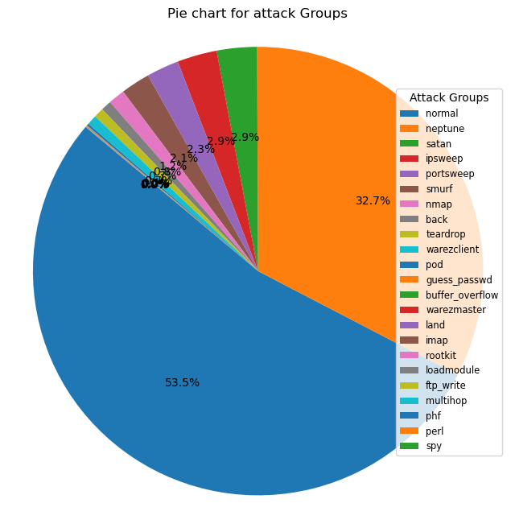

```python
fig, axes = plt.subplots(figsize=(8, 8))
attack_counts = data.attack.value_counts() #attack counts
plt.pie(attack_counts, autopct='%1.1f%%', startangle=140)
plt.title('Pie chart for attack Groups')
plt.legend(attack_counts.index, loc="right", fontsize='small', title="Attack Groups")
plt.axis('equal')
plt.show()
```

After observing the pie chart, it's evident that our dataset exhibits class imbalance, with "normal" comprising 53% and "neptune" representing 32% of the data. The remaining classes are distributed among smaller proportions. To rectify this imbalance and simplify our classification task, I propose merging the "normal" class with the smaller ones, along with combining "neptune" into a single class labeled "malicious." Consequently, our dataset will be reduced to two classes: "normal" and "malicious." This transformation maintains the integrity of the "normal" class while consolidating all other classes, including "neptune" and the smaller ones, into the "malicious" category. As a result, we'll achieve a binary classification problem focusing on distinguishing between "normal" and "malicious" instances.

```python
def merge_classes(class_label):
    if class_label == 'normal':
        return 'normal'
    else:
        return 'malicious'

# Applying the function to the 'attack' column
data['attack'] = data['attack'].apply(merge_classes)
```

### CORRELATION MATRIX

To comprehend the correlation plot, I will analyze the relationship between two variables and determine if it's proportional (greater than 0.5), inversely proportional (less than -0.5), or indicates no significant relation (close to zero). Understanding these correlations is crucial for improving model accuracy, as including less important columns can introduce bias or compromise the model's integrity.

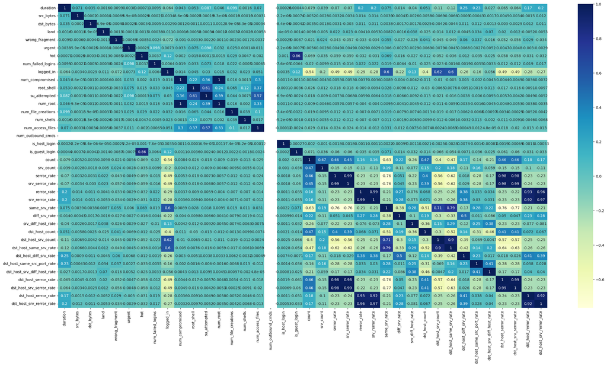

```python
# Calculate correlation matrix
numeric_data = data.select_dtypes(include='number')
# Calculate correlation matrix
corr_matrix = numeric_data.corr()
plt.figure(figsize=(30,15))
sns.heatmap(corr_matrix, annot=True, cmap="YlGnBu")
```

Upon examination, I observed that connection-related features exhibit high correlation, particularly concerning rates, while host-based traffic features also display significant correlation, especially concerning destinations. This insight suggests that the model might benefit from focusing on these highly correlated features to enhance predictive performance.

```python
print(data.isnull().values.any())
```

```
False
```

```python
data.dtypes
```

```
duration                         int64
protocol_type                   object
service                         object
flag                            object
src_bytes                        int64
dst_bytes                        int64
land                             int64
wrong_fragment                   int64
urgent                           int64
hot                              int64
num_failed_logins                int64
logged_in                        int64
num_compromised                  int64
root_shell                       int64
su_attempted                     int64
num_root                         int64
num_file_creations               int64
num_shells                       int64
num_access_files                 int64
num_outbound_cmds                int64
is_host_login                    int64
is_guest_login                   int64
count                            int64
srv_count                        int64
serror_rate                    float64
srv_serror_rate                float64
rerror_rate                    float64
srv_rerror_rate                float64
same_srv_rate                  float64
diff_srv_rate                  float64
srv_diff_host_rate             float64
dst_host_count                   int64
dst_host_srv_count               int64
dst_host_same_srv_rate         float64
dst_host_diff_srv_rate         float64
dst_host_same_src_port_rate    float64
dst_host_srv_diff_host_rate    float64
dst_host_serror_rate           float64
dst_host_srv_serror_rate       float64
dst_host_rerror_rate           float64
dst_host_srv_rerror_rate       float64
attack                          object
dtype: object
```

Upon inspecting the data types in our dataset, I noticed that the columns 'protocol_type', 'service', 'flag', and 'attack' are of object type. However, to feed this data into a neural network following the guidelines outlined by François Chollet in "Deep Learning with Python" from Part 1, all data entered into the network must be numeric. Therefore, I will convert these object-type columns to numeric using a label encoder.

```python
# Initialize label encoder
label_encoder = LabelEncoder()

# Convert object-type columns to numeric using label encoder
data['protocol_type'] = label_encoder.fit_transform(data['protocol_type'])
data['service'] = label_encoder.fit_transform(data['service'])
data['flag'] = label_encoder.fit_transform(data['flag'])
data['attack'] = label_encoder.fit_transform(data['attack'])
```

```python
data.dtypes
```

```
duration                         int64
protocol_type                    int32
service                          int32
flag                             int32
src_bytes                        int64
dst_bytes                        int64
land                             int64
wrong_fragment                   int64
urgent                           int64
hot                              int64
num_failed_logins                int64
logged_in                        int64
num_compromised                  int64
root_shell                       int64
su_attempted                     int64
num_root                         int64
num_file_creations               int64
num_shells                       int64
num_access_files                 int64
num_outbound_cmds                int64
is_host_login                    int64
is_guest_login                   int64
count                            int64
srv_count                        int64
serror_rate                    float64
srv_serror_rate                float64
rerror_rate                    float64
srv_rerror_rate                float64
same_srv_rate                  float64
diff_srv_rate                  float64
srv_diff_host_rate             float64
dst_host_count                   int64
dst_host_srv_count               int64
dst_host_same_srv_rate         float64
dst_host_diff_srv_rate         float64
dst_host_same_src_port_rate    float64
dst_host_srv_diff_host_rate    float64
dst_host_serror_rate           float64
dst_host_srv_serror_rate       float64
dst_host_rerror_rate           float64
dst_host_srv_rerror_rate       float64
attack                           int32
dtype: object
```

All our data is numeric now, after applying the label encoder to the object-type columns, the categorical data was transformed into numeric format, enabling for utilization of it as input for the neural network. This preprocessing step ensures that our dataset adheres to the requirements for training a neural network according to the principles outlined by François Chollet

#### Detect Outliers

Identifying outliers in the dataset, is crucial for maintaining data integrity, preserving model performance, and enhancing interpretability. I employed two methods: boxplot identification and standardization. After inspecting the boxplots, I chose to address outliers in the 'duration' column by replacing them with the median value. This approach avoids losing significant data while effectively handling corrupted outliers. The 'duration' column is critical for analysis, but the presence of numerous zeros and unacceptable instances can impact model performance. By replacing outliers with the median value, I ensure data remains representative, improving the efficiency and accuracy of subsequent analyses.

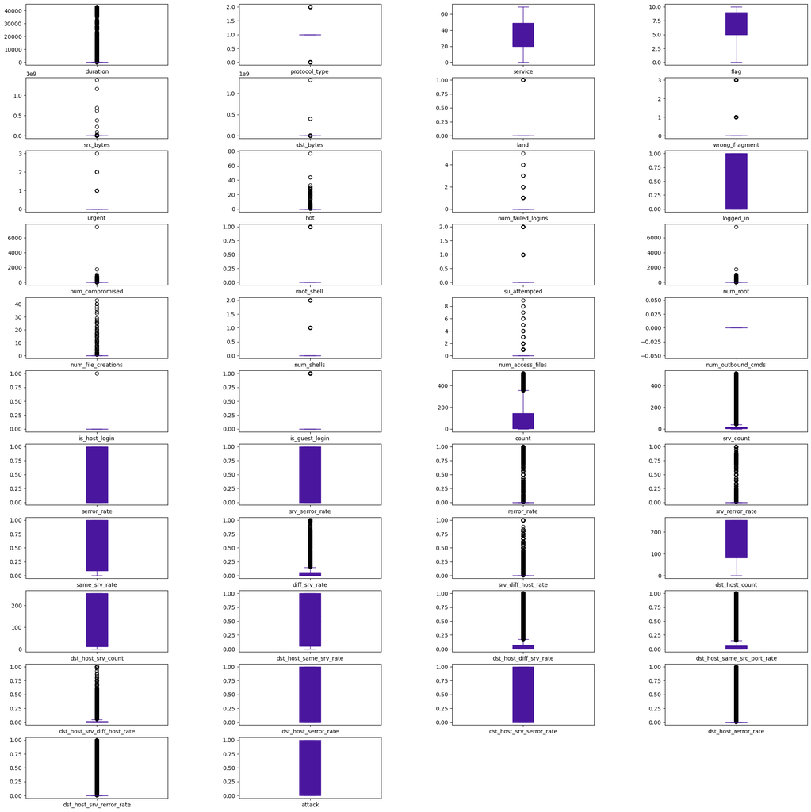

```python
data.plot(subplots = True , kind ='box', layout = (15,4), figsize = (25,35), patch_artist= True ,color = "#4A169E")
plt.subplots_adjust(wspace = 0.5)
plt.style.use("ggplot")
plt.show()
```

```python
# Filtering rows based on conditions
data_filtered = data[(data['dst_bytes'] <= 1500) & (data['src_bytes'] <= 750)]
# Finding quantiles
duration_quantile_10 = data_filtered['duration'].quantile(0.10)
duration_quantile_97 = data_filtered['duration'].quantile(0.97)
# Conditional replacement
data.loc[data['duration'] > duration_quantile_97, 'duration'] = 0
```

```python
data.describe()
```

|  | duration | protocol_type | service | flag | src_bytes | dst_bytes | land | wrong_fragment | urgent | hot | ... | dst_host_srv_count | dst_host_same_srv_rate | dst_host_diff_srv_rate | dst_host_same_src_port_rate | dst_host_srv_diff_host_rate | dst_host_serror_rate | dst_host_srv_serror_rate | dst_host_rerror_rate | dst_host_srv_rerror_rate | attack |
| --- | --- | --- | --- | --- | --- | --- | --- | --- | --- | --- | --- | --- | --- | --- | --- | --- | --- | --- | --- | --- | --- |
| count | 125972.000000 | 125972.000000 | 125972.000000 | 125972.00000 | 1.259720e+05 | 1.259720e+05 | 125972.000000 | 125972.000000 | 125972.000000 | 125972.000000 | ... | 125972.000000 | 125972.000000 | 125972.000000 | 125972.000000 | 125972.000000 | 125972.000000 | 125972.000000 | 125972.000000 | 125972.000000 | 125972.000000 |
| mean | 0.436899 | 1.053202 | 31.226558 | 6.97998 | 4.556710e+04 | 1.977927e+04 | 0.000198 | 0.022688 | 0.000111 | 0.204411 | ... | 115.653725 | 0.521244 | 0.082952 | 0.148379 | 0.032543 | 0.284455 | 0.278487 | 0.118832 | 0.120241 | 0.534579 |
| std | 2.998405 | 0.426621 | 16.346504 | 2.68937 | 5.870354e+06 | 4.021285e+06 | 0.014086 | 0.253531 | 0.014366 | 2.149977 | ... | 110.702886 | 0.448950 | 0.188922 | 0.308998 | 0.112564 | 0.444785 | 0.445670 | 0.306559 | 0.319460 | 0.498805 |
| min | 0.000000 | 0.000000 | 0.000000 | 0.00000 | 0.000000e+00 | 0.000000e+00 | 0.000000 | 0.000000 | 0.000000 | 0.000000 | ... | 0.000000 | 0.000000 | 0.000000 | 0.000000 | 0.000000 | 0.000000 | 0.000000 | 0.000000 | 0.000000 | 0.000000 |
| 25% | 0.000000 | 1.000000 | 20.000000 | 5.00000 | 0.000000e+00 | 0.000000e+00 | 0.000000 | 0.000000 | 0.000000 | 0.000000 | ... | 10.000000 | 0.050000 | 0.000000 | 0.000000 | 0.000000 | 0.000000 | 0.000000 | 0.000000 | 0.000000 | 0.000000 |
| 50% | 0.000000 | 1.000000 | 24.000000 | 9.00000 | 4.400000e+01 | 0.000000e+00 | 0.000000 | 0.000000 | 0.000000 | 0.000000 | ... | 63.000000 | 0.510000 | 0.020000 | 0.000000 | 0.000000 | 0.000000 | 0.000000 | 0.000000 | 0.000000 | 1.000000 |
| 75% | 0.000000 | 1.000000 | 49.000000 | 9.00000 | 2.760000e+02 | 5.160000e+02 | 0.000000 | 0.000000 | 0.000000 | 0.000000 | ... | 255.000000 | 1.000000 | 0.070000 | 0.060000 | 0.020000 | 1.000000 | 1.000000 | 0.000000 | 0.000000 | 1.000000 |
| max | 43.000000 | 2.000000 | 69.000000 | 10.00000 | 1.379964e+09 | 1.309937e+09 | 1.000000 | 3.000000 | 3.000000 | 77.000000 | ... | 255.000000 | 1.000000 | 1.000000 | 1.000000 | 1.000000 | 1.000000 | 1.000000 | 1.000000 | 1.000000 | 1.000000 |

8 rows × 42 columns

### Data Summary Analysis

Based on the summary obtained from `data.describe()`, it's evident that the numerical columns display considerable variations in their value ranges. Notably, 'src_bytes' and 'dst_bytes' exhibit extensive ranges, with maximum values reaching into the billions, while 'duration' ranges from 0 to 43. Additionally, both 'src_bytes' and 'dst_bytes' demonstrate large standard deviations, indicating substantial variability within the dataset.

### Standardization and Scaling

To address these discrepancies and ensure equitable contributions of features to the model, I intend to implement scaling or normalization techniques on the entire dataset. By standardizing or scaling all features to a comparable range, we can enhance the effectiveness of subsequent modeling tasks. Furthermore, standardization is crucial for preventing features with larger values from unduly influencing parameter updates during optimization processes, particularly in gradient-based algorithms like those used in neural networks. By standardizing all features to a similar scale, we can ensure that each feature contributes proportionally to parameter updates, thereby fostering a more balanced optimization process.

```python
#splitting the data into leabels and features
#LABELS
labels_unique = data['attack'].unique()
labels = data['attack']
y = np.asarray(labels).astype('float32')

#FEATURES
features = data.drop(['attack'] , axis = 1)
cols= features.columns
#X = pd.get_dummies(features)

# Separate data into partial training and validation before scaling to prevent data leakage
X_train, X_test, y_train, y_test = train_test_split(features, y, test_size=0.2, random_state=42)
X_train_partial, X_val, y_train_partial, y_val = train_test_split(X_train, y_train, test_size=0.1, random_state=42)

# Scaling
ro_scaler = RobustScaler()

X_train_partial = ro_scaler.fit_transform(X_train_partial)
X_val = ro_scaler.transform(X_val)
X_test = ro_scaler.transform(X_test)
```

### Selection of RobustScaler for Scaling

My decision to use RobustScaler instead of F. Chollet's method of calculating the mean and standard deviation was driven by the presence of outliers in the dataset, as indicated by the box plots I analyzed earlier. Although I addressed outliers in the 'duration' column by replacing them with the median value, it became evident that other columns still contained outliers. Addressing outliers individually for each column might have been insufficient, especially given the presence of outliers in multiple columns. Hence, the need for a more robust scaling technique arose. By opting for RobustScaler, I aimed to mitigate the influence of outliers on the scaling process. This approach ensures that the scaling is less affected by extreme values, resulting in more reliable and stable scaling for model training and performance evaluation.

```python
X_train.shape #(100777, 41) 41 features
y_test.shape # (25195,)
```

```
(25195,)
```

## NEURAL NETWORK ARCHITECTURE

(Fig3.1 from DLWP by F.Chollet Chapter 3)

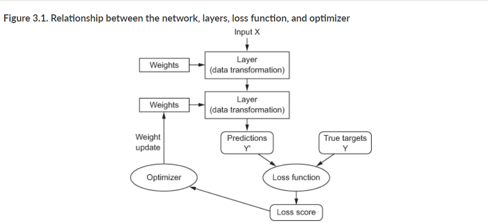

To implement the theoretical principles outlined in the book "Deep Learning with Python" by F. Chollet, as evident from Fig 3.1 above, I will begin by initializing the neural network with a minimal number of hidden units, serving as the starting point for the optimization process.

Understanding that training a multi-layer neural network can be conceptualized as a convex optimization problem in certain scenarios, such as binary classification with a sigmoid activation for the output layer and binary cross-entropy loss function, the objective is to minimize a weighted sum of errors using convex optimization principles.

Finally, I will validate the theoretical insights and algorithmic approach through rigorous experimentation. This will involve conducting experiments to evaluate the performance of the trained neural network across various conditions and comparing it with established methodologies.

### BASELINE MODEL

For this baseline i will just start with something simple, 2 Dense layers each with 16 neurons with a sigmoid activation for the output layer since its a binary classification. And for the validation, I will be using the train-validation split method to validate the model's performance. This method involves splitting the dataset into training and validation sets, allowing for model evaluation without the risk of data leakage. Given the sufficient amount of data available, employing other validation techniques like k-fold cross-validation or iterated k-fold may not be necessary. Moreover, using a train-validation split simplifies the validation process and saves computational resources compared to more complex cross-validation techniques. Additionally, this method provides a good balance between variance and bias in estimating the model's performance, making it suitable for the current scenario.

```python
inputs = X_train.shape[1]
model = models.Sequential()
model.add(layers.Dense(16, activation='relu', input_shape=(inputs,)))
model.add(layers.Dense(16, activation='relu'))
model.add(layers.Dense(1, activation='sigmoid'))
model.summary
```

```
<bound method Model.summary of <keras.src.engine.sequential.Sequential object at 0x000001AFE8DFB9D0>>
```

```python
model.compile(optimizer=optimizers.RMSprop(learning_rate=0.001),
              loss='binary_crossentropy',
              metrics=['accuracy', tf.keras.metrics.Recall()])
```

```python
#TRAINING THE MODEL

history = model.fit(X_train_partial,
                    y_train_partial,
                    epochs=50,
                    batch_size=128,
                    validation_data=(X_val, y_val))
# Saving the model
model.save('baseline_model.keras')
print("Baseline model saved successfully.")
```

```
Baseline model saved successfully.
```

```python
baseline_model = load_model("baseline_model.keras")
hist = history.history
hist.keys()
overfit_epoch = np.argmax(hist['val_accuracy']) + 1
print("Overfitting started at epoch: ", overfit_epoch)
loss, accuracy, recall = baseline_model.evaluate(X_test, y_test)
```

```
Overfitting started at epoch:  46
```

```python
def plot_learning_val( train_data, val_data, ylabel):
        """
        Plot the learning curves for training and validation data.

        Parameters:
        - train_data (list): List of training data for each epoch.
        - val_data (list): List of validation data for each epoch.
        - ylabel (str): Label for the y-axis.
        """
        epochs = range(1, len(train_data) + 1)
        plt.figure(figsize=(12, 5))

        plt.subplot(1, 2, 1)
        plt.plot(epochs, train_data,label="Training")
        plt.plot(epochs, val_data,label="Validation")
        plt.xlabel('Epochs')
        plt.ylabel(ylabel)
        plt.title('Training and Validation Performance: ' + ylabel)
        plt.legend()

        plt.subplot(1, 2, 2)
        plt.plot(epochs[-10:], train_data[-10:], label="Training")
        plt.plot(epochs[-10:], val_data[-10:], label="Validation")
        plt.xlabel('Epochs')
        plt.ylabel(ylabel)
        plt.title('Last 10 Epochs Performance: ' + ylabel)
        plt.legend()

        plt.tight_layout()
        plt.show()
```

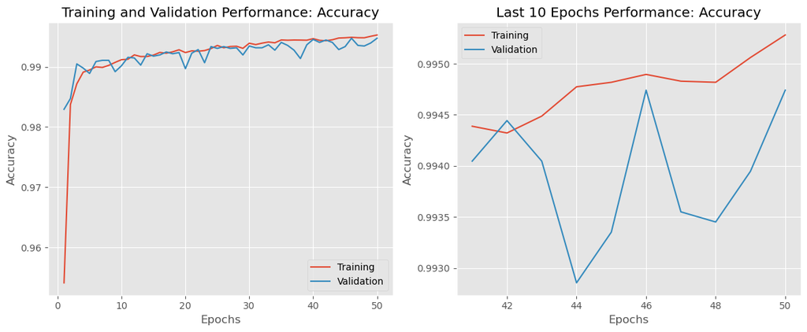

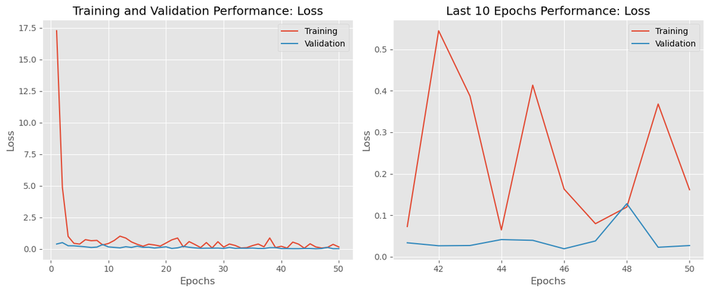

```python
plot_learning_val(hist['accuracy'], hist['val_accuracy'], "Accuracy")
plot_learning_val(hist['loss'], hist['val_loss'], "Loss")
```

### EXPERIMENT 1

Now in an attempt to improve my model's performance i will increase the number of neurons in my two layers from 16 to 128 for the first layer and 64 for the second layer while everything else remain the same. Additionally, I will implement a learning rate scheduler function to dynamically adjust the learning rate during training based on the validation accuracy. This function will monitor the validation accuracy and halve the learning rate if the accuracy fails to improve over a specified number of epochs (with a patience of 4). Such an approach is anticipated to facilitate improved model convergence and performance by adapting the learning rate dynamically. Lastly, considering that overfitting commenced at epoch 46, I will curtail the number of epochs for subsequent training to 40 and introduce a dropout layer. This dropout layer will help prevent overfitting by randomly setting a fraction(in tis next experiment 25%)of input units to 0 during training, thereby reducing interdependence between neurons and promoting better generalization.

```python
learning_rate_reduction = ReduceLROnPlateau(monitor='val_accuracy',
                                            patience=4,
                                            verbose=1,
                                            factor=0.5,
                                            min_lr=0.00001)

model = models.Sequential()
model.add(layers.Dense(128, activation='relu', input_shape=(inputs,)))
model.add(layers.Dropout(0.25))
model.add(layers.Dense(64, activation='relu'))
model.add(layers.Dropout(0.25))
model.add(layers.Dense(1, activation='sigmoid'))
model.summary
```

```
<bound method Model.summary of <keras.src.engine.sequential.Sequential object at 0x000001AFF4974C40>>
```

```python
model.compile(optimizer=optimizers.RMSprop(learning_rate=0.001),
              loss='binary_crossentropy',
              metrics=['accuracy', tf.keras.metrics.Recall()])

#TRAINING THE MODEL
history = model.fit(X_train_partial,
                    y_train_partial,
                    epochs=40,
                    batch_size=128,
                    validation_data=(X_val, y_val), callbacks = [learning_rate_reduction])
# Saving the model
model.save('exp1_model.keras')
print("Experiemnt model saved successfully.")
```

```
Epoch 17: ReduceLROnPlateau reducing learning rate to 0.0005000000237487257.
Epoch 31: ReduceLROnPlateau reducing learning rate to 0.0002500000118743628.
Epoch 35: ReduceLROnPlateau reducing learning rate to 0.0001250000059371814.
Experiemnt model saved successfully.
```

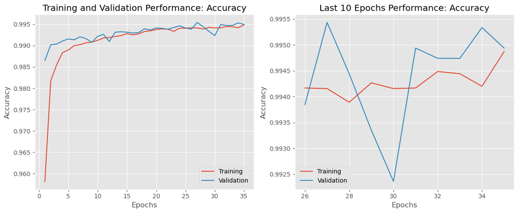

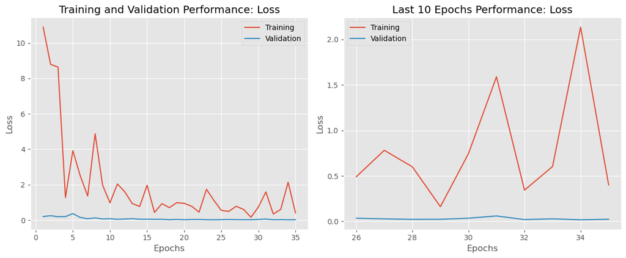

```python
hist= history.history
plot_learning_val(hist['accuracy'], hist['val_accuracy'], "Accuracy")
plot_learning_val(hist['loss'], hist['val_loss'], "Loss")
```

```python
exp1_model = load_model('exp1_model.keras')
loss, accuracy, recall = exp1_model.evaluate(X_test, y_test)#loss: 0.2134 - accuracy: 0.9954 - recall_1: 0.9969
```

## Experiment 1 Results and Observations

The improved performance in experiment 1 can be attributed to the increased model capacity afforded by the larger neuron count, enabling the capture of more intricate data patterns. Additionally, the dynamic adjustment of the learning rate based on validation accuracy likely facilitated better convergence during training.

### EXPERIMENT 2

In Experiment 2, I will make several adjustments to refine the model architecture and improve performance. Firstly, I will change the activation function for the second layer from ReLU to tanh, aiming to introduce non-linearity and enhance the model's ability to capture complex patterns in the data. Additionally, in response to the high loss observed in Experiment 1, I plan on reducing the number of neurons in the first layer from 128 to 64. This adjustment aims to strike a balance between model complexity and performance, as Experiment 1's model might have been overly complex, while the baseline model was too simplistic.Furthermore, in addition to dropout regularization, l2 regularization will also be employed. I chose L2 regularization because of its ability to address overfitting by penalizing large weight values in the model. This regularization technique will contribute to preventing the model from becoming too sensitive to the training data, thus improving its generalization capabilities.

```python
learning_rate_reduction = ReduceLROnPlateau(monitor='val_accuracy',
                                            patience=4,
                                            verbose=1,
                                            factor=0.5,
                                            min_lr=0.00001)

inputs = X_train.shape[1]
model = models.Sequential()
model.add(layers.Dense(64, activation='relu', input_shape=(inputs,)))
model.add(layers.Dropout(0.25))
model.add(layers.Dense(64, activation='tanh',kernel_regularizer=tf.keras.regularizers.l2(0.001)))
model.add(layers.Dropout(0.25))
model.add(layers.Dense(1, activation='sigmoid'))
model.summary
```

```
<bound method Model.summary of <keras.src.engine.sequential.Sequential object at 0x000001AFE89C8F10>>
```

```python
model.compile(optimizer=optimizers.RMSprop(learning_rate=0.001),
              loss='binary_crossentropy',
              metrics=['accuracy', tf.keras.metrics.Recall()])

#TRAINING THE MODEL
history_exp2 = model.fit(X_train_partial,
                    y_train_partial,
                    epochs=40,
                    batch_size=128,
                    validation_data=(X_val, y_val), callbacks = [learning_rate_reduction])
# Save the model
model.save('exp2_model.keras')
print("Experiemnt2 model saved successfully.")
```

```
Epoch 10: ReduceLROnPlateau reducing learning rate to 0.0005000000237487257.
Epoch 14: ReduceLROnPlateau reducing learning rate to 0.0002500000118743628.
Epoch 18: ReduceLROnPlateau reducing learning rate to 0.0001250000059371814.
Epoch 26: ReduceLROnPlateau reducing learning rate to 6.25000029685907e-05.
Epoch 30: ReduceLROnPlateau reducing learning rate to 3.125000148429535e-05.
Epoch 34: ReduceLROnPlateau reducing learning rate to 1.5625000742147677e-05.
Experiemnt2 model saved successfully.
```

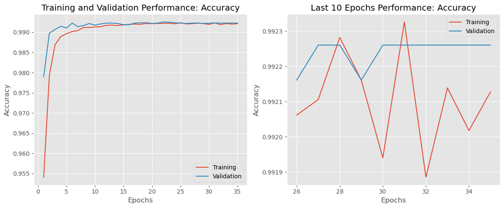

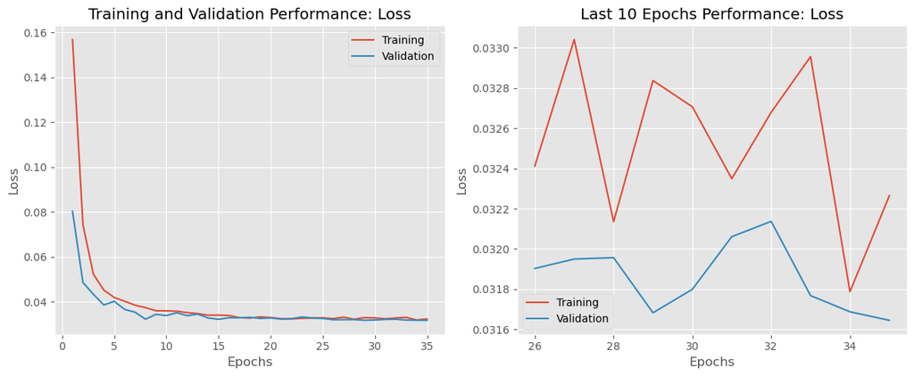

```
Overfitting started at epoch: 22
```

```python
hist = history_exp2.history
plot_learning_val(hist['accuracy'], hist['val_accuracy'], "Accuracy")
plot_learning_val(hist['loss'], hist['val_loss'], "Loss")
overfit_epoch = np.argmax(hist['val_accuracy']) + 1
print("Overfitting started at epoch:", overfit_epoch)
exp2_model = load_model('exp2_model.keras')
loss, accuracy, recall = exp2_model.evaluate(X_test, y_test)
```

## EXPERIMNT 2 RESULTS AND OBSERVATIONS

As a result of those modifications, Experiment 2 yielded promising results, with a reduced loss of 0.0313, an accuracy of 99.23%, and a recall of 99.33%. Comparing Experiment 2 to the previous model, there was a notable improvement in loss, indicating better convergence and model refinement. The decision to decrease the number of neurons and change the activation function appears to have yielded a more optimal model architecture. Moving forward, the focus will be on fine-tuning hyperparameters to further optimize model performance. To accomplish this, I plan to utilize parameter grid search, a systematic approach that exhaustively searches through a predefined grid of hyperparameters to identify the optimal combination. While other methods like random search or Bayesian optimization are viable options, parameter grid search provides a comprehensive exploration of hyperparameter space, ensuring thorough optimization and yielding more reliable results. Thus, parameter grid search is the preferred method for determining the most suitable hyperparameters for the model.

### GRID SEARCH FOR HYPER PARAMETER TUNING

```python
# Model architecture
def create_model(optimizer=RMSprop, learning_rate=0.001):
    if optimizer == RMSprop:
        opt = RMSprop(learning_rate=learning_rate)
    elif optimizer == Adam:
        opt = Adam(learning_rate=learning_rate)
    elif optimizer == Adagrad:
        opt = Adagrad(learning_rate=learning_rate)
    else:
        raise ValueError("Invalid optimizer")

    model = models.Sequential()
    model.add(layers.Dense(64, activation='relu', input_shape=(inputs,)))
    model.add(layers.Dropout(0.2))
    model.add(layers.Dense(64, activation='tanh',kernel_regularizer=tf.keras.regularizers.l2(0.0001)))
    model.add(layers.Dropout(0.2))
    model.add(layers.Dense(1, activation='sigmoid'))
    #compiling the model
    model.compile(optimizer=opt,loss='binary_crossentropy',metrics=['accuracy', tf.keras.metrics.Recall()])
    return model

inputs = X_train_partial.shape[1]
# KerasClassifier wrapper so we can use sklearn libraries
model = KerasClassifier(build_fn=create_model, verbose=1)

learning_rates = [0.001, 0.01, 0.0001]
optimizers = [RMSprop, Adam, Adagrad]
param_combinations = list(product(learning_rates, optimizers))

# Grid search parameters
param_grid = {
    'optimizer': optimizers,
    'batch_size': [32, 64, 128],
    'epochs': [20, 30, 40]
}
#  fitTING the grid search
grid = GridSearchCV(estimator=model, param_grid=param_grid, n_jobs=-1, cv=3)
grid_result = grid.fit(X_train_partial, y_train_partial)

# Results summary
print("Best: %f using %s" % (grid_result.best_score_, grid_result.best_params_))
means = grid_result.cv_results_['mean_test_score']
stds = grid_result.cv_results_['std_test_score']
params = grid_result.cv_results_['params']
for mean, stdev, param in zip(means, stds, params):
    print("%f (%f) with: %r" % (mean, stdev, param))
```

```
Best: 0.994123 using {'batch_size': 128, 'epochs': 40, 'optimizer': <class 'keras.src.optimizers.adagrad.Adagrad'>}
0.992073 (0.000439) with: {'batch_size': 32, 'epochs': 20, 'optimizer': <class 'keras.src.optimizers.rmsprop.RMSprop'>}
0.992690 (0.000108) with: {'batch_size': 32, 'epochs': 20, 'optimizer': <class 'keras.src.optimizers.adam.Adam'>}
0.992414 (0.000255) with: {'batch_size': 32, 'epochs': 20, 'optimizer': <class 'keras.src.optimizers.adagrad.Adagrad'>}
0.992701 (0.000041) with: {'batch_size': 32, 'epochs': 30, 'optimizer': <class 'keras.src.optimizers.rmsprop.RMSprop'>}
0.992966 (0.000133) with: {'batch_size': 32, 'epochs': 30, 'optimizer': <class 'keras.src.optimizers.adam.Adam'>}
0.992668 (0.000174) with: {'batch_size': 32, 'epochs': 30, 'optimizer': <class 'keras.src.optimizers.adagrad.Adagrad'>}
0.992381 (0.000790) with: {'batch_size': 32, 'epochs': 40, 'optimizer': <class 'keras.src.optimizers.rmsprop.RMSprop'>}
0.992547 (0.000671) with: {'batch_size': 32, 'epochs': 40, 'optimizer': <class 'keras.src.optimizers.adam.Adam'>}
0.992900 (0.000112) with: {'batch_size': 32, 'epochs': 40, 'optimizer': <class 'keras.src.optimizers.adagrad.Adagrad'>}
0.992701 (0.000226) with: {'batch_size': 64, 'epochs': 20, 'optimizer': <class 'keras.src.optimizers.rmsprop.RMSprop'>}
0.992657 (0.000389) with: {'batch_size': 64, 'epochs': 20, 'optimizer': <class 'keras.src.optimizers.adam.Adam'>}
0.992944 (0.000316) with: {'batch_size': 64, 'epochs': 20, 'optimizer': <class 'keras.src.optimizers.adagrad.Adagrad'>}
0.993462 (0.000125) with: {'batch_size': 64, 'epochs': 30, 'optimizer': <class 'keras.src.optimizers.rmsprop.RMSprop'>}
0.993495 (0.000180) with: {'batch_size': 64, 'epochs': 30, 'optimizer': <class 'keras.src.optimizers.adam.Adam'>}
0.993285 (0.000124) with: {'batch_size': 64, 'epochs': 30, 'optimizer': <class 'keras.src.optimizers.adagrad.Adagrad'>}
0.993837 (0.000286) with: {'batch_size': 64, 'epochs': 40, 'optimizer': <class 'keras.src.optimizers.rmsprop.RMSprop'>}
0.992955 (0.000992) with: {'batch_size': 64, 'epochs': 40, 'optimizer': <class 'keras.src.optimizers.adam.Adam'>}
0.993638 (0.000244) with: {'batch_size': 64, 'epochs': 40, 'optimizer': <class 'keras.src.optimizers.adagrad.Adagrad'>}
0.993010 (0.000297) with: {'batch_size': 128, 'epochs': 20, 'optimizer': <class 'keras.src.optimizers.rmsprop.RMSprop'>}
0.992900 (0.000255) with: {'batch_size': 128, 'epochs': 20, 'optimizer': <class 'keras.src.optimizers.adam.Adam'>}
0.993440 (0.000378) with: {'batch_size': 128, 'epochs': 20, 'optimizer': <class 'keras.src.optimizers.adagrad.Adagrad'>}
0.993826 (0.000109) with: {'batch_size': 128, 'epochs': 30, 'optimizer': <class 'keras.src.optimizers.rmsprop.RMSprop'>}
0.992933 (0.000852) with: {'batch_size': 128, 'epochs': 30, 'optimizer': <class 'keras.src.optimizers.adam.Adam'>}
0.993826 (0.000315) with: {'batch_size': 128, 'epochs': 30, 'optimizer': <class 'keras.src.optimizers.adagrad.Adagrad'>}
0.993892 (0.000149) with: {'batch_size': 128, 'epochs': 40, 'optimizer': <class 'keras.src.optimizers.rmsprop.RMSprop'>}
0.993936 (0.000556) with: {'batch_size': 128, 'epochs': 40, 'optimizer': <class 'keras.src.optimizers.adam.Adam'>}
0.994123 (0.000322) with: {'batch_size': 128, 'epochs': 40, 'optimizer': <class 'keras.src.optimizers.adagrad.Adagrad'>}
```

### TRAINING WITH THE BEST PARAMETERS FROM GRIDSEARCH AND ON ALL TRAINING DATA

```python
## TRAINING WITH THE BEST PARAMETERS FROM GRIDSEARCH AND ON ALL TRAINING DATA
# best parameters found during the grid search
best_params = grid_result.best_params_

# Creating the model with the best parameters
best_model = create_model(optimizer=best_params['optimizer'])
best_batch_size = best_params['batch_size']
best_epochs = best_params['epochs']


# Concatenate X_train_partial and X_val
X_train_final = np.concatenate((X_train_partial, X_val), axis=0)
y_train_final = np.concatenate((y_train_partial, y_val), axis=0)

# Train the model on the ALL training data
hist_best_model = best_model.fit(X_train_final, y_train_final, batch_size=best_batch_size, epochs=best_epochs, verbose=1)

# Save the updated model
best_model.save('final_trained_model.keras')

print("Final trained model saved successfully.")
```

```
Final trained model saved successfully.
```

```python
best_optimizer = best_params['optimizer']
best_batch_size = best_params['batch_size']
best_epochs = best_params['epochs']
print("Best optimizer:", best_optimizer, "Best batch_size:",best_batch_size, "Best epochs:", best_epochs)
hist= hist_best_model.history

loss = hist['loss']
accuracy = hist['accuracy']
hist.keys()
recall = hist['recall_2']
```

```
Best optimizer: <class 'keras.src.optimizers.adagrad.Adagrad'> Best batch_size: 128 Best epochs: 40
```

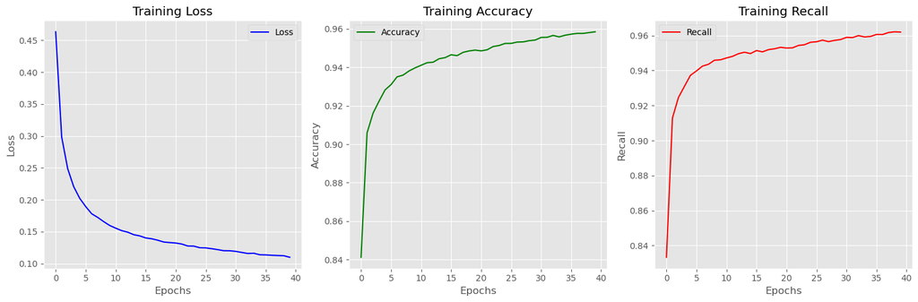

```python
# Create subplots
fig, axs = plt.subplots(1, 3, figsize=(15, 5))

# Plot loss
axs[0].plot(loss, label='Loss', color='blue')
axs[0].set_title('Training Loss')
axs[0].set_xlabel('Epochs')
axs[0].set_ylabel('Loss')
axs[0].legend()

# Plot accuracy
axs[1].plot(accuracy, label='Accuracy', color='green')
axs[1].set_title('Training Accuracy')
axs[1].set_xlabel('Epochs')
axs[1].set_ylabel('Accuracy')
axs[1].legend()

# Plot recall
axs[2].plot(recall, label='Recall', color='red')
axs[2].set_title('Training Recall')
axs[2].set_xlabel('Epochs')
axs[2].set_ylabel('Recall')
axs[2].legend()

plt.tight_layout()
plt.show()
```

```python
# Load the best model
loaded_model = load_model('final_trained_model.keras')

# Evaluate the loaded model
evaluation = loaded_model.evaluate(X_test, y_test)

# Print the evaluation metrics
print("Test Loss:", evaluation[0])
print("Test Accuracy:", evaluation[1])
print("Test Recall:", evaluation[2])
```

```
Test Loss: 0.08883737027645111
Test Accuracy: 0.97392338514328
Test Recall: 0.9711639285087585
```

### Measuring False Negatives

As false negatives significantly impact my model's performance due to their consequences, I will assess the percentage of false negatives. To compute this, I'll utilize the ground truth labels and the predictions generated by my model. By comparing these, I'll identify cases where the model predicted a negative outcome (e.g., non-intrusion) while the ground truth indicated a positive outcome (e.g., intrusion). Subsequently, I'll calculate the percentage of false negatives using the following formula:

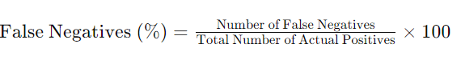

```python
# Predictions using unseen data
y_pred = loaded_model.predict(X_test)
# Convert predicted probabilities to binary predictions
y_pred = np.round(y_pred).tolist()

# Calculate confusion matrix
conf_matrix_final = confusion_matrix(y_test, y_pred)

tn, fp, fn, tp = conf_matrix_final.ravel()

#  percentage of false negatives
false_negatives_percent = (fn / (fn + tp)) * 100

print("Percentage of False Negatives:", false_negatives_percent)
```

```
Percentage of False Negatives: 2.883609741520992
```

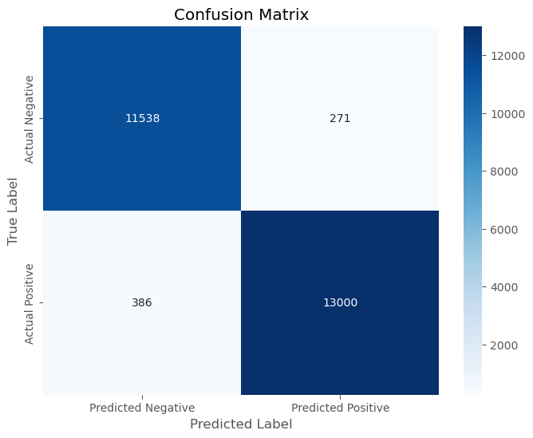

```python
# Confusion Matrix
plt.figure(figsize=(8, 6))
sns.heatmap(conf_matrix_final, annot=True, fmt='g', cmap='Blues',
            xticklabels=['Predicted Negative', 'Predicted Positive'],
            yticklabels=['Actual Negative', 'Actual Positive'])
plt.xlabel('Predicted Label')
plt.ylabel('True Label')
plt.title('Confusion Matrix')
plt.show()
```

```python
# Calculate fraction error
label_frac_error = 1 - np.diag(conf_matrix_final) / np.sum(conf_matrix_final, axis=1)
label_frac_error_percentage = label_frac_error * 100

# Plot fraction error
plt.bar(np.arange(2), label_frac_error_percentage)
plt.title("FRACTION ERROR FOR TEST DATASET")
plt.xlabel('Class Label')
plt.ylabel('Fraction classified incorrectly (%)')
plt.xticks(np.arange(2), ['0 (Normal)', '1 (Malicious)'])
plt.show()
```

[output not shown]

## BEST MODEL RESULTS

**CONFUSION MATRIX ANALYSIS** The confusion matrix analysis of the model's performance reveals several key findings. Despite achieving a high number of true positives (TP = 13000) and true negatives (TN = 11538), signifying its ability to correctly identify both intrusions and non-intrusions, the presence of 386 false negatives (FN) highlights a significant area for improvement. False negatives, where the model incorrectly predicts non-intrusions when the ground truth indicates intrusions, can have severe consequences in intrusion detection systems.

## PRINCIPLE COMPONENT ANALYSIS (PCA)

In an effort to mitigate the occurrence of false negatives and further enhance the model's performance, the application of Principal Component Analysis (PCA) to the feature set presents a promising avenue. Despite the model's already impressive results, PCA offers the opportunity to reduce the dimensionality of the feature space while retaining most of the data variance. By transforming the original features into a new set of orthogonal components, PCA can facilitate more efficient computation,and most importantly improve model interpretability, and uncover hidden patterns or clusters within the data. And lastly based on the observation i made earlier from the correlation matrix, that connection-related features exhibited high correlation, particularly concerning rate.This insight suggests that the model might benefit from focusing on these highly correlated features to enhance predictive performance thus the use PCA to extract those highly correlated features. This exploration aligns with the objective of developing a more robust and adaptable Intrusion Detection System (IDS) capable of effectively identifying and mitigating emerging cyber threats.

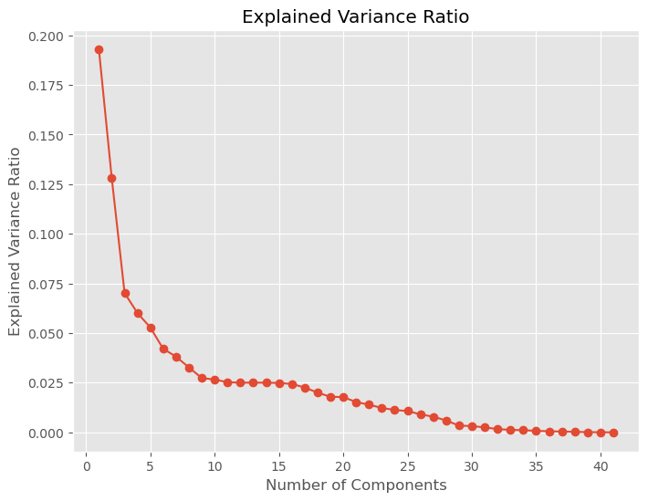

```
Desired Variance: 0.95
Actual Variance Explained: 0.95
Number of Components Selected: 24
```

```python
# Perform data preprocessing (scaling)
data_pca =  data.drop(['attack'], axis=1)
scaler = StandardScaler()
data_scaled = scaler.fit_transform(data_pca)

# Perform PCA
pca = PCA()
pca.fit(data_scaled)

# Visualize explained variance ratio
plt.figure(figsize=(8, 6))
plt.plot(range(1, len(pca.explained_variance_ratio_) + 1), pca.explained_variance_ratio_, marker='o', linestyle='-')
plt.title('Explained Variance Ratio')
plt.xlabel('Number of Components')
plt.ylabel('Explained Variance Ratio')
plt.show()

#  the desired variance to be explained
desired_variance = 0.95

# Initialize and fit  PCA with the desired variance
pca = PCA(n_components=desired_variance, svd_solver='full')
data_pca= pca.fit_transform(data_scaled)

# Get the actual variance explained by the selected components
actual_variance = pca.explained_variance_ratio_.sum()
num_components = pca.n_components_

print(f"Desired Variance: {desired_variance:.2f}")
print(f"Actual Variance Explained: {actual_variance:.2f}")
print(f"Number of Components Selected: {num_components}")

# Get the principal axes in feature space
principal_axes = pca.components_
# Get the original column names of the selected components
selected_component_indices = range(len(pca.explained_variance_ratio_))
selected_column_names = cols[selected_component_indices]
data_pca_df = pd.DataFrame(data_pca, columns=selected_column_names)
```

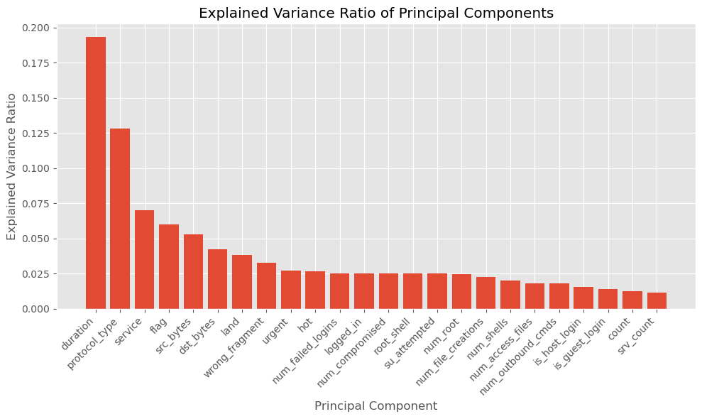

```python
plt.figure(figsize=(10, 6))
plt.bar(selected_column_names, pca.explained_variance_ratio_)
plt.xlabel('Principal Component')
plt.ylabel('Explained Variance Ratio')
plt.title('Explained Variance Ratio of Principal Components')
plt.xticks(rotation=45, ha='right')  # Rotate labels for better readability
plt.grid(True)
plt.tight_layout()  # Adjust layout to prevent overlap
plt.show()
```

```python
data_pca_df
```

|  | duration | protocol_type | service | flag | src_bytes | dst_bytes | land | wrong_fragment | urgent | hot | ... | su_attempted | num_root | num_file_creations | num_shells | num_access_files | num_outbound_cmds | is_host_login | is_guest_login | count | srv_count |
| --- | --- | --- | --- | --- | --- | --- | --- | --- | --- | --- | --- | --- | --- | --- | --- | --- | --- | --- | --- | --- | --- |
| 0 | 0.587494 | 0.700464 | 0.048654 | 0.272451 | -0.382566 | 0.807396 | -4.126664 | 0.401470 | -0.204607 | 0.398759 | ... | 0.255523 | -0.122426 | -0.053769 | -1.885339 | -0.310417 | -0.966394 | 0.122539 | -0.737374 | -0.170631 | 0.040658 |
| 1 | 3.638288 | -1.992306 | 0.031347 | -0.019870 | 0.358910 | -0.521108 | 0.062904 | 0.047138 | 0.067052 | -0.125861 | ... | -0.084232 | 0.000060 | -0.010697 | 0.085028 | -0.153693 | -0.286923 | -0.049829 | 0.021140 | 0.197630 | 0.079140 |
| 2 | -2.617914 | -0.620832 | -0.068796 | -0.215965 | -0.043909 | -1.012355 | 0.525960 | 0.096509 | -0.052572 | 0.154006 | ... | 0.061590 | -0.059081 | 0.023243 | -0.102958 | -0.451842 | 0.742274 | -0.080438 | 0.600928 | 0.496010 | -0.526075 |
| 3 | -2.407137 | -0.536364 | -0.122788 | -0.146825 | -1.144572 | -0.504668 | 0.458639 | 0.031333 | -0.153694 | 0.310925 | ... | 0.122360 | 0.034218 | 0.029160 | 0.395102 | -0.035671 | 0.114756 | 0.098033 | -0.424712 | -0.267222 | 0.567298 |
| 4 | 2.720206 | 5.541951 | -0.005666 | 0.015437 | -0.652174 | -0.674311 | 1.383940 | -0.112568 | 0.273676 | -0.711323 | ... | -0.236882 | 0.072474 | 0.063492 | 0.415213 | -0.357429 | -0.754934 | -0.001399 | -0.248983 | -0.196037 | 0.391819 |
| ... | ... | ... | ... | ... | ... | ... | ... | ... | ... | ... | ... | ... | ... | ... | ... | ... | ... | ... | ... | ... | ... |
| 125967 | 3.681868 | -1.993222 | 0.008038 | -0.086337 | 0.214136 | -0.136361 | 0.146735 | -0.016709 | 0.060879 | -0.076056 | ... | -0.086109 | 0.030489 | -0.028989 | 0.250006 | -0.216893 | -0.361724 | -0.080099 | 0.132337 | 0.343519 | 0.031836 |
| 125968 | -1.684424 | -0.359682 | -0.029557 | 1.255490 | -1.745112 | -0.509191 | -0.934596 | 0.248004 | 0.377418 | -0.606748 | ... | 0.124880 | -0.084231 | -0.124937 | -0.755036 | 0.551544 | -1.831008 | -0.425422 | 1.774776 | -0.612739 | 0.617282 |
| 125969 | -0.406485 | -0.641525 | 0.132690 | 0.414486 | -0.388959 | -1.259959 | -0.956368 | 0.114438 | -0.046529 | 0.196159 | ... | -0.075258 | 0.115831 | -0.070952 | 0.626991 | -1.195417 | -0.762447 | 0.149789 | -0.584919 | -0.333715 | 1.093822 |
| 125970 | 3.571171 | -2.035459 | -0.029519 | -0.060212 | 0.328468 | -0.095914 | 0.425958 | 0.008475 | 0.059070 | -0.179563 | ... | -0.051200 | -0.055054 | 0.046493 | -0.353384 | 0.155694 | 0.224039 | 0.073932 | -0.116197 | -0.261846 | -0.033867 |
| 125971 | -1.557229 | -0.314583 | -0.023911 | 0.161028 | -0.403944 | -0.298712 | -0.486670 | 0.073999 | -0.120830 | 0.214876 | ... | 0.017671 | -0.017630 | 0.027518 | -0.287745 | -0.708677 | 0.177260 | 0.368560 | -0.991165 | -1.216764 | 0.596533 |

125972 rows × 24 columns

### PCA RESULTS AND OBSERVATIONS

Furthermore, the graphical representation of the explained variance ratios corroborates these findings, providing a visual depiction of the relative importance of each feature. PCA has greatly facilitated the visualization and analysis of feature relationships vis-à-vis model outcomes, thereby enhancing the interpretability of the model. This improved interpretability aids in comprehending the decision-making process of the model, shedding light on the factors driving its predictions.

Moving forward, i will move forward and feed these selected components as features in my model.

```python
# Separate data into training and testing
X_train_pca, X_test_pca, y_train_pca, y_test_pca = train_test_split(data_pca_df, y, test_size=0.2, random_state=42)
X_train_pca.shape
```

```
(100777, 24)
```

```python
# Create the model with the best parameters
inputs_pca = X_train_pca.shape[1]
# Model architecture
def create_model_pca(optimizer=RMSprop, learning_rate=0.001):
    if optimizer == RMSprop:
        opt = RMSprop(learning_rate=learning_rate)
    elif optimizer == Adam:
        opt = Adam(learning_rate=learning_rate)
    elif optimizer == Adagrad:
        opt = Adagrad(learning_rate=learning_rate)
    else:
        raise ValueError("Invalid optimizer")

    model = models.Sequential()
    model.add(layers.Dense(64, activation='relu', input_shape=(inputs_pca,)))
    model.add(layers.Dropout(0.2))
    model.add(layers.Dense(64, activation='tanh'))
    model.add(layers.Dropout(0.2))
    model.add(layers.Dense(1, activation='sigmoid'))
    model.compile(optimizer=opt,
                  loss='binary_crossentropy',
                  metrics=['accuracy', tf.keras.metrics.Recall()])
    return model





model_pca = create_model_pca(optimizer=best_params['optimizer'])

hist_pca = model_pca.fit(X_train_pca, y_train_pca, batch_size=best_batch_size, epochs=best_epochs, verbose=1)
# Save the updated model
model_pca.save('model_pca.keras')

print("PCA Trained model saved successfully.")
```

```
PCA Trained model saved successfully.
```

```python
model_pca = load_model("model_pca.keras")
# Evaluate the loaded model
evaluation = model_pca.evaluate(X_test_pca, y_test_pca)

# Print the evaluation metrics
print("Test Loss:", evaluation[0])
print("Test Accuracy:", evaluation[1])
print("Test Recall:", evaluation[2])
#loss: 0.0170 - accuracy: 0.9955 - recall_3: 0.9963
```

```
Test Loss: 0.0863361582159996
Test Accuracy: 0.9709069132804871
Test Recall: 0.9890183806419373
```

```python
y_pred = model_pca.predict(X_test_pca)
# Convert predicted probabilities to binary predictions
y_pred = np.round(y_pred).tolist()

# Calculate confusion matrix
conf_matrix = confusion_matrix(y_test_pca, y_pred)

tn, fp, fn, tp = conf_matrix.ravel()

#  percentage of false negatives
false_negatives_percent = (fn / (fn + tp)) * 100

print("Percentage of False Negatives:", false_negatives_percent)
fn
```

```
Percentage of False Negatives: 1.098162259076647
```

```
147
```

```python
hist= hist_pca.history
print(hist.keys())
```

```
dict_keys(['loss', 'accuracy', 'recall_4'])
```

```python
# Extract loss, accuracy, and recall from the history dictionary
loss = hist['loss']
accuracy = hist['accuracy']
recall = hist['recall_4']
```

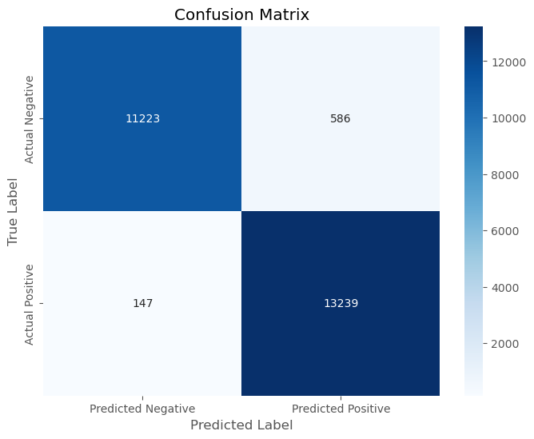

```python
# Confusion Matrix
plt.figure(figsize=(8, 6))
sns.heatmap(conf_matrix, annot=True, fmt='g', cmap='Blues',
            xticklabels=['Predicted Negative', 'Predicted Positive'],
            yticklabels=['Actual Negative', 'Actual Positive'])
plt.xlabel('Predicted Label')
plt.ylabel('True Label')
plt.title('Confusion Matrix')
plt.show()
```

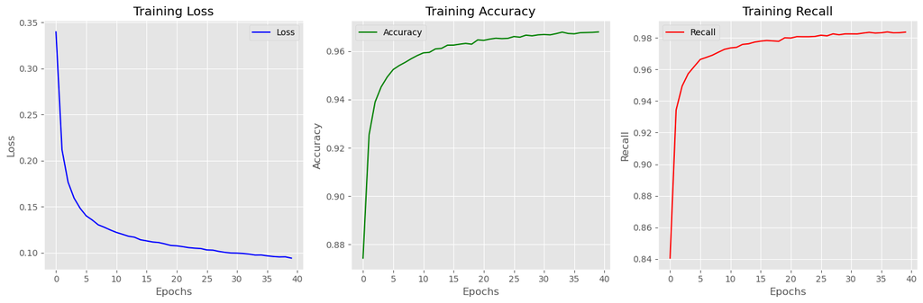

```python
# Create subplots
fig, axs = plt.subplots(1, 3, figsize=(15, 5))

# Plot loss
axs[0].plot(loss, label='Loss', color='blue')
axs[0].set_title('Training Loss')
axs[0].set_xlabel('Epochs')
axs[0].set_ylabel('Loss')
axs[0].legend()

# Plot accuracy
axs[1].plot(accuracy, label='Accuracy', color='green')
axs[1].set_title('Training Accuracy')
axs[1].set_xlabel('Epochs')
axs[1].set_ylabel('Accuracy')
axs[1].legend()

# Plot recall
axs[2].plot(recall, label='Recall', color='red')
axs[2].set_title('Training Recall')
axs[2].set_xlabel('Epochs')
axs[2].set_ylabel('Recall')
axs[2].legend()

# Adjust layout
plt.tight_layout()

# Show the plot
plt.show()
```

## RESULTS AND OBSERVATION FOR PCA MODEL

### General Project Conclusion:

The project successfully achieved its objectives by designing and implementing an Intrusion Detection System (IDS) using TensorFlow's Sequential model. The model was trained on labeled network traffic data to distinguish between normal and anomalous behavior. The evaluation metrics, particularly accuracy and false-negative rates, were used to assess the model's performance.

The achieved results align with the project's aims, showcasing the significance of advanced methodologies, such as PCA, in improving model robustness. The project lays the groundwork for future enhancements and optimizations, emphasizing the continuous evolution and adaptation required to combat cybersecurity threats effectively.